# kestrel data

Trevor Caughlin

2022-04-14

## Dispersal

In this presentation, we will be modeling dispersal of American Kestrels using data from McCaslin 2020.

## Data details

- Banding and encounter data from the US Geological Survey’s Bird Banding Laboratory
- All kestrels banded in the United States or Canada from 1961 to 2015
- n=329,987 kestrels banded,5,329 (1.6%) of those birds were subsequently reported.
- define natal dispersers as ‘local’ (nestling) or ‘hatch year’ birds banded during the breeding season (1 April–15 August) and encountered during the breeding season 1 year later.

## Load the data

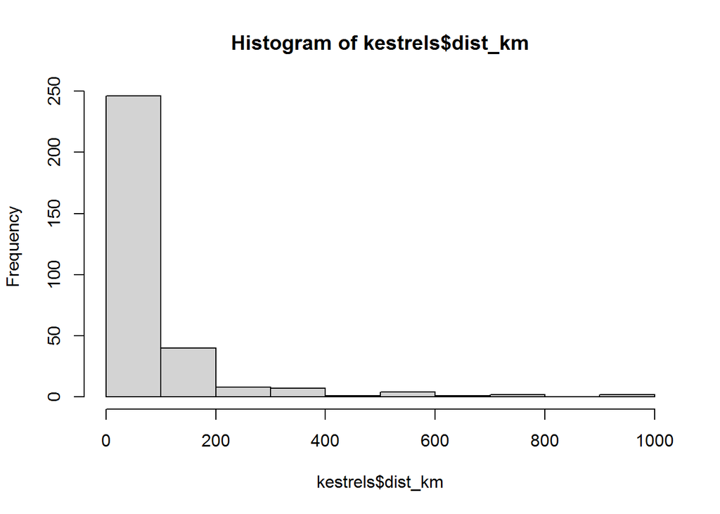

```r
kestrels=read.csv("mccaslin_kestrel_final_dataset_archive.csv")
hist(kestrels$dist_km)
```

What do these data tell us about natal dispersal for kestrels?

## Fit gamma regression

To quantify effects of covariates, we will use a gamma regression to model distance. Note that the original paper used a cut off of 30 km to define long vs. short dispersal.

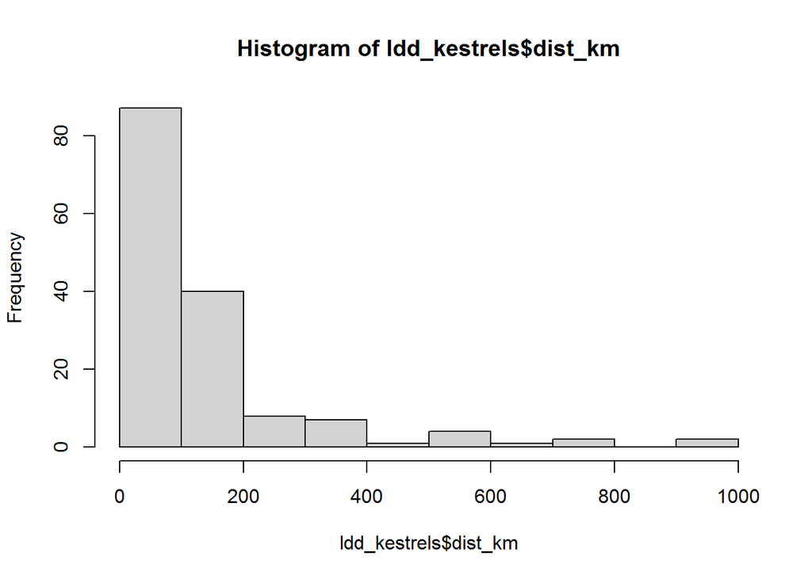

```
##
## Call:
## glm(formula = dist_km ~ extE, family = Gamma(link = "log"), data = ldd_kestrels)
##
## Deviance Residuals:
##      Min        1Q    Median        3Q       Max
## -1.35078  -0.82229  -0.46005   0.01055   2.64095
##
## Coefficients:
##             Estimate Std. Error t value Pr(>|t|)
## (Intercept)   5.2415     0.1434  36.555  < 2e-16 ***
## extE         -0.8988     0.3117  -2.883  0.00452 **
## ---
## Signif. codes:  0 '***' 0.001 '**' 0.01 '*' 0.05 '.' 0.1 ' ' 1
##
## (Dispersion parameter for Gamma family taken to be 1.196138)
##
##     Null deviance: 119.42  on 151  degrees of freedom
## Residual deviance: 110.49  on 150  degrees of freedom
## AIC: 1791.2
##
## Number of Fisher Scoring iterations: 6
```

What are some of the advantages and disadvantages of modeling with a gamma distribution?

**In class activity: fit a gamma model to one or more of the covariates. What do your results show?**

## How much better do the fat-tailed distributions fit, relative to the gamma?

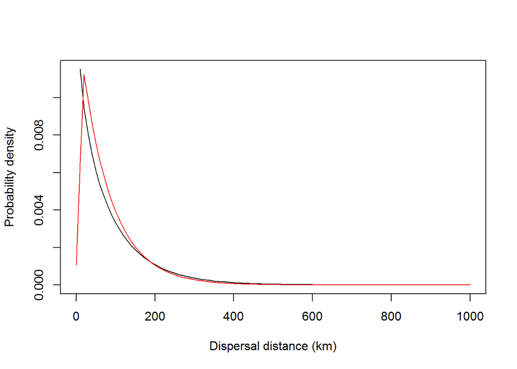

**Assignment**: using the half-cauchy distribution in the extraDistr package [https://www.rdocumentation.org/packages/extraDistr/versions/1.9.1/topics/HalfCauchy] fit a half-cauchy distribution to the kestral natal dispersal data.

1. calculate AIC and compare with the log-sech and gamma distribution. Which distribution provides the best fit to the data?
2. Add a curved line for the half-cauchy to the plot. How does the visual fit of the data compare?